# Module02

An Example:

```r
penguins_subset <- mutate(penguins, bill_ratio = bill_length_mm / bill_depth_mm)
penguins_final <- filter(penguins_subset, species == "Adelie")
```

OR we can simply write:

```r
penguins_final <- penguins |>
  mutate(bill_ratio = bill_length_mm / bill_depth_mm) |>
  filter(species == "Adelie")
```

By using the pipe, the code becomes easier to read, easier to debug, and much more efficient to write.

1.7.5 Computing new attributes with mutate()

```r
#Calculate a new morphological ratio in our environment
penguin_ratios <- penguins |>
  mutate(body_mass_kg = body_mass_g / 1000, #convert grams to kilograms
         bill_ratio = bill_length_mm / bill_depth_mm #bill ratio
         )

#View the newly engineered variables appended to the far-right columns.
glimpse(penguin_ratios)
```

```
## Rows: 344
## Columns: 10
## $ species           <fct> Adelie, Adelie, Adelie, Adelie, Adelie, Adelie, Adel…
## $ island            <fct> Torgersen, Torgersen, Torgersen, Torgersen, Torgerse…
## $ bill_length_mm    <dbl> 39.1, 39.5, 40.3, NA, 36.7, 39.3, 38.9, 39.2, 34.1, …
## $ bill_depth_mm     <dbl> 18.7, 17.4, 18.0, NA, 19.3, 20.6, 17.8, 19.6, 18.1, …
## $ flipper_length_mm <int> 181, 186, 195, NA, 193, 190, 181, 195, 193, 190, 186…
## $ body_mass_g       <int> 3750, 3800, 3250, NA, 3450, 3650, 3625, 4675, 3475, …
## $ sex               <fct> male, female, female, NA, female, male, female, male…
## $ year              <int> 2007, 2007, 2007, 2007, 2007, 2007, 2007, 2007, 2007…
## $ body_mass_kg      <dbl> 3.750, 3.800, 3.250, NA, 3.450, 3.650, 3.625, 4.675,…
## $ bill_ratio        <dbl> 2.090909, 2.270115, 2.238889, NA, 1.901554, 1.907767…
```

#1.8 Data aggregation and ecological summarisation Isolating and sorting individual rows or columns allows us to clean and audit a dataset, but it does not tell you the broader or underlying ecological story. To extract meaningful biological conclusions - such as determining whether morphological allometry varies by species or island group-you must compress thousands of individual observations into into explicit population summary metrics.

This is achieved using the dual-layered combination of group_by() and summarise().

```r
#Grouping our active memory penguins by species
grouped_penguins <- group_by(penguins, species)

#Notice that the table looks identical, but the metadata notes 'Groups: species [3]'
print(grouped_penguins)
```

```
## # A tibble: 344 × 8
## # Groups:   species [3]
##    species island    bill_length_mm bill_depth_mm flipper_length_mm body_mass_g
##    <fct>   <fct>              <dbl>         <dbl>             <int>       <int>
##  1 Adelie  Torgersen           39.1          18.7               181        3750
##  2 Adelie  Torgersen           39.5          17.4               186        3800
##  3 Adelie  Torgersen           40.3          18                 195        3250
##  4 Adelie  Torgersen           NA            NA                  NA          NA
##  5 Adelie  Torgersen           36.7          19.3               193        3450
##  6 Adelie  Torgersen           39.3          20.6               190        3650
##  7 Adelie  Torgersen           38.9          17.8               181        3625
##  8 Adelie  Torgersen           39.2          19.6               195        4675
##  9 Adelie  Torgersen           34.1          18.1               193        3475
## 10 Adelie  Torgersen           42            20.2               190        4250
## # ℹ 334 more rows
## # ℹ 2 more variables: sex <fct>, year <int>
```

```r
#Collapsing the buckets into explicit summary metrics
species_mass_summary <- summarise(grouped_penguins,
                                  mean_mass_g = mean(body_mass_g)
)

print(species_mass_summary)
```

```
## # A tibble: 3 × 2
##   species   mean_mass_g
##   <fct>           <dbl>
## 1 Adelie            NA
## 2 Chinstrap       3733.
## 3 Gentoo            NA
```

The printout summary operation failed and returned an entire column of NA values for certain groups! This is an essential behavioural design feature of R known as the Missing Value Trap. If a column contains even a single missing observation flag (NA) any mathematical aggregation function (such as mean(), sd(), or sum()) will automatically return NA to protect you from miscalculating metrics on incomplete data. To override this, we must explicitly declare that missing cells should be dropped during calculation. We’ll use the magrittr pipe to wrangle our data, avoiding the missing value trap.

```r
#Overcoming the missing value trap using na.rm = TRUE
biological_signal <- penguins %>%
  group_by(species, sex) %>%
  summarise(
    sample_size = n(), #count total individuals per category
    mean_mass_g = mean(body_mass_g, na.rm = TRUE), #calculate mean ignoring missing cells
    sd_mass_g = sd(body_mass_g, na.rm = TRUE) #standard deviation calculation
  )
```

```
## `summarise()` has regrouped the output.
## ℹ Summaries were computed grouped by species and sex.
## ℹ Output is grouped by species.
## ℹ Use `summarise(.groups = "drop_last")` to silence this message.
## ℹ Use `summarise(.by = c(species, sex))` for per-operation grouping
##   (`?dplyr::dplyr_by`) instead.
```

```r
print(biological_signal)
```

```
## # A tibble: 8 × 5
## # Groups:   species [3]
##   species   sex    sample_size mean_mass_g sd_mass_g
##   <fct>     <fct>        <int>       <dbl>     <dbl>
## 1 Adelie    female          73       3369.      269.
## 2 Adelie    male            73       4043.      347.
## 3 Adelie    <NA>             6       3540       477.
## 4 Chinstrap female          34       3527.      285.
## 5 Chinstrap male            34       3939.      362.
## 6 Gentoo    female          58       4680.      282.
## 7 Gentoo    male            61       5485.      313.
## 8 Gentoo    <NA>             5       4588.      338.
```

#1.9 Integrating data grammar with visual diagnostics in qmd 1.9.1 Wrangling and Plotting in Parallel We will combine the pipe (|>) and the basics of ggplot2 into a single reproducible block.

Challenge: Visualing Body Size and Shape Using data loaded, create a code chunk in your .qmd that performs the following 2 tasks simultaneously:

1. Summary Table: Pipe your data to group_by() and summarise() to calculate the mean body mass for each species and island AND 2. Visualisation: pipe the same dataset into ggplot() to create a boxplot of body_mass_g by species, with the island variable mapped to fill or facet_wrap().

```
## `summarise()` has regrouped the output.
## ℹ Summaries were computed grouped by species and island.
## ℹ Output is grouped by species.
## ℹ Use `summarise(.groups = "drop_last")` to silence this message.
## ℹ Use `summarise(.by = c(species, island))` for per-operation grouping
##   (`?dplyr::dplyr_by`) instead.
```

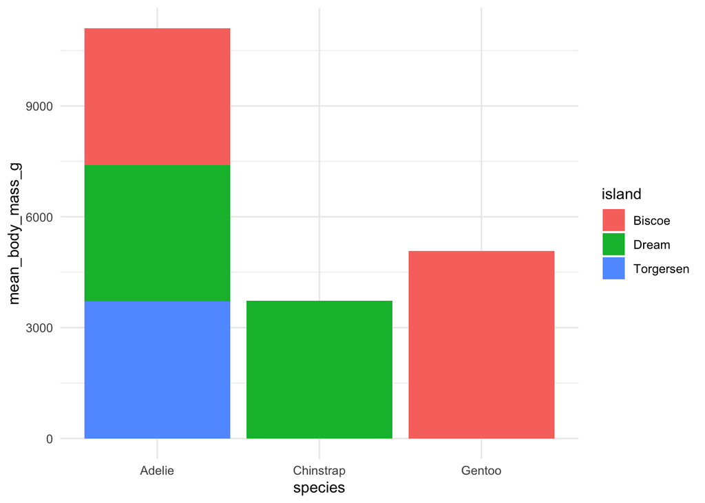

```r
#penguin_figure_body_mass <-
  penguins |>
  group_by(species, island) |>
  summarise(mean_body_mass_g = mean(body_mass_g, na.rm = TRUE)) |>
  ggplot(aes(x = species, y = mean_body_mass_g, fill = island)) +
  geom_col() +
  theme_minimal()
```

1.9.2 Piping Directly to Visualisation Sometimes, you do not need to save a summary table as an object. If your goal is to visualse patterns and uncertainty within your aggregated data, you can extend your pipeline directly into ggplot2.

Example: Visualising Mean Trends with Uncertainty - instead of creating a summary table object first, you can pipe your grouped data straight into a plot using geom_errorbar() to represent the spread of your data:

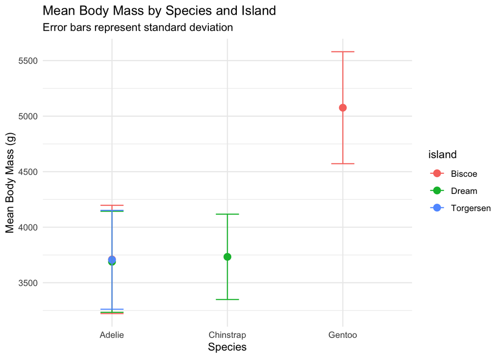

```r
#pipe directly from aggregation to plotting with error bars
mass_compare_plot <- penguins |>
  group_by(species, island) |>
  summarise(
    mean_mass = mean(body_mass_g, na.rm = TRUE),
    sd_mass = sd(body_mass_g, na.rm = TRUE),
    n = n(),
    .groups = "drop"
  ) |>
  ggplot(aes(x = species, y = mean_mass, colour = island)) +
  geom_point(size = 3) +
  geom_errorbar(aes(ymin = mean_mass - sd_mass,
                    ymax = mean_mass + sd_mass),
                width = 0.2) +
  labs(title = "Mean Body Mass by Species and Island",
       subtitle = "Error bars represent standard deviation",
       y = "Mean Body Mass (g)",
       x = "Species") +
  theme_minimal()

mass_compare_plot
```

The above graph is showing that Adelie & Chinstrap penguins have similar mean body masses. It is also showing that Adelie penguins on each of the islands have similar mean body masses. And it is showing that Gentoo penguins have a larger mean body mass compared to the other two penguin species.

Challenge: Create a new plot. Swap sd_mass (standard deviation) for standard error (sd/sqrt(n)). See how it changes the visual interpretation of the data uncertainty.

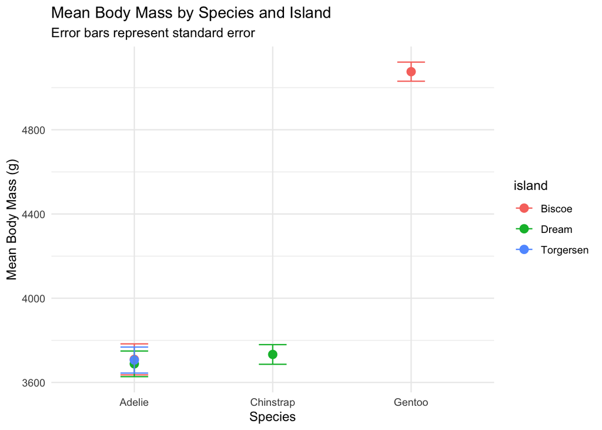

```r
#pipe directly from aggregation to plotting with error bars
mass_sterror_plot <- penguins |>
  group_by(species, island) |>
  summarise(
    mean_mass = mean(body_mass_g, na.rm = TRUE),
    sd_mass = sd(body_mass_g, na.rm = TRUE),
    n = n(),
    se_mass = (sd_mass/sqrt(n)),
    .groups = "drop"
  ) |>
  ggplot(aes(x = species, y = mean_mass, colour = island)) +
  geom_point(size = 3) +
  geom_errorbar(aes(ymin = mean_mass - se_mass,
                    ymax = mean_mass + se_mass),
                width = 0.2) +
  labs(title = "Mean Body Mass by Species and Island",
       subtitle = "Error bars represent standard error",
       y = "Mean Body Mass (g)",
       x = "Species") +
  theme_minimal()

mass_sterror_plot
```

#1.10 Saving, exporting and version milestones

```r
#Create output directories if they do not exist:
if(!dir.exists("output")) dir.create("output")
if(!dir.exists("output/figures")) dir.create("output/figures") #folder for figures
if(!dir.exists("output/tables")) dir.create("output/tables") #folder for tables
if(!dir.exists("Rdata")) dir.create("Rdata") #folder for Rdata objects
```

TABLES

```r
#1. Exporting our collapsed summary table as a universal flat text file.
write_csv(biological_signal, "output/tables/penguin_species_mass_summary.csv")

#2. Saving out cleaned morphological cohort table as a native R binary file
saveRDS(penguins_final,"output/tables/penguins_final.rds")
```

FIGURES

```r
ggsave("output/figures/mass_compare_plot.png",
       plot = mass_compare_plot,
       width = 120, height = 120,
       units = "mm", dpi = 300)
```

#### Workshop 6

```r
library(dplyr)
library(stringr)
library(lubridate)
library(tidyverse)
library(tidyr)
```

#2.2 Tidying Data

Tables

```r
table1
```

```
## # A tibble: 6 × 4
##   country      year  cases population
##   <chr>       <dbl>  <dbl>      <dbl>
## 1 Afghanistan  1999    745   19987071
## 2 Afghanistan  2000   2666   20595360
## 3 Brazil       1999  37737  172006362
## 4 Brazil       2000  80488  174504898
## 5 China        1999 212258 1272915272
## 6 China        2000 213766 1280428583
```

```r
table2
```

```
## # A tibble: 12 × 4
##    country      year type            count
##    <chr>       <dbl> <chr>           <dbl>
##  1 Afghanistan  1999 cases             745
##  2 Afghanistan  1999 population   19987071
##  3 Afghanistan  2000 cases            2666
##  4 Afghanistan  2000 population   20595360
##  5 Brazil       1999 cases           37737
##  6 Brazil       1999 population  172006362
##  7 Brazil       2000 cases           80488
##  8 Brazil       2000 population  174504898
##  9 China        1999 cases          212258
## 10 China        1999 population 1272915272
## 11 China        2000 cases          213766
## 12 China        2000 population 1280428583
```

```r
table3
```

```
## # A tibble: 6 × 3
##   country      year rate
##   <chr>       <dbl> <chr>
## 1 Afghanistan  1999 745/19987071
## 2 Afghanistan  2000 2666/20595360
## 3 Brazil       1999 37737/172006362
## 4 Brazil       2000 80488/174504898
## 5 China        1999 212258/1272915272
## 6 China        2000 213766/1280428583
```

```r
#Compute rate per 10,000
table1 %>%
  mutate(rate = cases/population * 10000)
```

```
## # A tibble: 6 × 5
##   country      year  cases population  rate
##   <chr>       <dbl>  <dbl>      <dbl> <dbl>
## 1 Afghanistan  1999    745   19987071 0.373
## 2 Afghanistan  2000   2666   20595360 1.29
## 3 Brazil       1999  37737  172006362 2.19
## 4 Brazil       2000  80488  174504898 4.61
## 5 China        1999 212258 1272915272 1.67
## 6 China        2000 213766 1280428583 1.67
```

```r
#Compute cases per year
table1 %>%
  count(year, wt = cases)
```

```
## # A tibble: 2 × 2
##    year      n
##   <dbl>  <dbl>
## 1  1999 250740
## 2  2000 296920
```

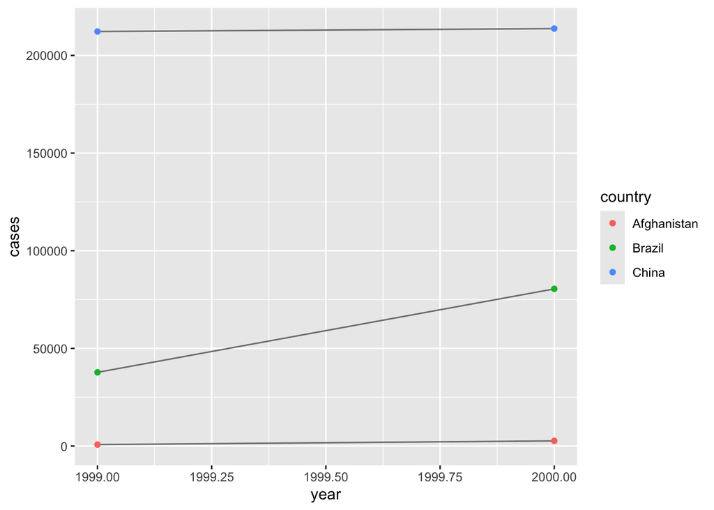

```r
#Visualise changes over time
library(ggplot2)
ggplot(table1, aes(year, cases)) +
  geom_line(aes(group = country), colour = "grey50") +
  geom_point(aes(colour = country))
```

#2.3 Pivoting data to make it tidy Use tidyr:pivot_longer() to lengthen data and pivot_wider() to widen data.

Lets see pivot_longer() in an example using the billboard dataset records ranking songs in the year 2000.

```r
billboard
```

```
## # A tibble: 317 × 79
##    artist     track date.entered   wk1   wk2   wk3   wk4   wk5   wk6   wk7   wk8
##    <chr>      <chr> <date>       <dbl> <dbl> <dbl> <dbl> <dbl> <dbl> <dbl> <dbl>
##  1 2 Pac      Baby… 2000-02-26      87    82    72    77    87    94    99    NA
##  2 2Ge+her    The … 2000-09-02      91    87    92    NA    NA    NA    NA    NA
##  3 3 Doors D… Kryp… 2000-04-08      81    70    68    67    66    57    54    53
##  4 3 Doors D… Loser 2000-10-21      76    76    72    69    67    65    55    59
##  5 504 Boyz   Wobb… 2000-04-15      57    34    25    17    17    31    36    49
##  6 98^0       Give… 2000-08-19      51    39    34    26    26    19     2     2
##  7 A*Teens    Danc… 2000-07-08      97    97    96    95   100    NA    NA    NA
##  8 Aaliyah    I Do… 2000-01-29      84    62    51    41    38    35    35    38
##  9 Aaliyah    Try … 2000-03-18      59    53    38    28    21    18    16    14
## 10 Adams, Yo… Open… 2000-08-26      76    76    74    69    68    67    61    58
## # ℹ 307 more rows
## # ℹ 68 more variables: wk9 <dbl>, wk10 <dbl>, wk11 <dbl>, wk12 <dbl>,
## #   wk13 <dbl>, wk14 <dbl>, wk15 <dbl>, wk16 <dbl>, wk17 <dbl>, wk18 <dbl>,
## #   wk19 <dbl>, wk20 <dbl>, wk21 <dbl>, wk22 <dbl>, wk23 <dbl>, wk24 <dbl>,
## #   wk25 <dbl>, wk26 <dbl>, wk27 <dbl>, wk28 <dbl>, wk29 <dbl>, wk30 <dbl>,
## #   wk31 <dbl>, wk32 <dbl>, wk33 <dbl>, wk34 <dbl>, wk35 <dbl>, wk36 <dbl>,
## #   wk37 <dbl>, wk38 <dbl>, wk39 <dbl>, wk40 <dbl>, wk41 <dbl>, wk42 <dbl>, …
```

The first step is to understand what each observation means, so we can be sure they are represented appropriatly as rows. In this data set, each observation is a song. The first three columns (artist, track & data.entered) are variables that describe the song. Then we have 76 columns (wk1-76) that described the rank of the song in eachweek. Here, the column names are one variable (the week) and the cell values are another (the rank). to tidy the billbaord data we will use pivot_longer().

```r
billboard |>
  pivot_longer(
    cols = starts_with("wk"),
    names_to = "week",
    values_to = "rank"
  )
```

```
## # A tibble: 24,092 × 5
##    artist track                   date.entered week   rank
##    <chr>  <chr>                   <date>       <chr> <dbl>
##  1 2 Pac  Baby Don't Cry (Keep... 2000-02-26   wk1      87
##  2 2 Pac  Baby Don't Cry (Keep... 2000-02-26   wk2      82
##  3 2 Pac  Baby Don't Cry (Keep... 2000-02-26   wk3      72
##  4 2 Pac  Baby Don't Cry (Keep... 2000-02-26   wk4      77
##  5 2 Pac  Baby Don't Cry (Keep... 2000-02-26   wk5      87
##  6 2 Pac  Baby Don't Cry (Keep... 2000-02-26   wk6      94
##  7 2 Pac  Baby Don't Cry (Keep... 2000-02-26   wk7      99
##  8 2 Pac  Baby Don't Cry (Keep... 2000-02-26   wk8      NA
##  9 2 Pac  Baby Don't Cry (Keep... 2000-02-26   wk9      NA
## 10 2 Pac  Baby Don't Cry (Keep... 2000-02-26   wk10     NA
## # ℹ 24,082 more rows
```

Now the data is in longform. We have the ranking of every song for every week E.g. Baby Don’t Cry by 2 Pac from week 1 to week 76 with its ranking. So, we have many more pages as it is in longform. cols = specifies the columns you want to pivot. names_to = which names the variable stored in the column names, we chose to name that variable ‘week’. values_to = which names the variable stored in the cell values that we named ‘rank’. There are a lot of NA values throughout the weeks, so make this go away we ass values_drop_na = TRUE.

```r
billboard |>
  pivot_longer(
    cols = starts_with("wk"),
    names_to = "week",
    values_to = "rank",
    values_drop_na = TRUE
  )
```

```
## # A tibble: 5,307 × 5
##    artist  track                   date.entered week   rank
##    <chr>   <chr>                   <date>       <chr> <dbl>
##  1 2 Pac   Baby Don't Cry (Keep... 2000-02-26   wk1      87
##  2 2 Pac   Baby Don't Cry (Keep... 2000-02-26   wk2      82
##  3 2 Pac   Baby Don't Cry (Keep... 2000-02-26   wk3      72
##  4 2 Pac   Baby Don't Cry (Keep... 2000-02-26   wk4      77
##  5 2 Pac   Baby Don't Cry (Keep... 2000-02-26   wk5      87
##  6 2 Pac   Baby Don't Cry (Keep... 2000-02-26   wk6      94
##  7 2 Pac   Baby Don't Cry (Keep... 2000-02-26   wk7      99
##  8 2Ge+her The Hardest Part Of ... 2000-09-02   wk1      91
##  9 2Ge+her The Hardest Part Of ... 2000-09-02   wk2      87
## 10 2Ge+her The Hardest Part Of ... 2000-09-02   wk3      92
## # ℹ 5,297 more rows
```

Now there are fewer rows and our data is tidy!

#Pivoting longer - example Let’s see how pivoting can help reshape and see what it actually does to our data.

```r
df <- tribble(
  ~id, ~bp1, ~bp2,
  "A", 100, 120,
  "B", 140, 115,
  "C", 120, 125
)
```

Here, we have created a dataset called ‘df’ with 3 variables and their associated values. However, we want our new tidy dataset to have 3 variables: 1. id (which already exists) 2. measurement (the column names) 3. value (the cell values) To make this happen we need to pivot df longer…

```r
df |>
  pivot_longer(
    cols = bp1:bp2,
    names_to = "measurement",
    values_to = "value"
  )
```

```
## # A tibble: 6 × 3
##   id    measurement value
##   <chr> <chr>       <dbl>
## 1 A     bp1           100
## 2 A     bp2           120
## 3 B     bp1           140
## 4 B     bp2           115
## 5 C     bp1           120
## 6 C     bp2           125
```

#2.5 Widening Datasets In less common cases, we may need to widen a dataset rather than lengthen it. Widening is the opposite of lengthening so we use the function pivot_wider(). It allows us to handle an observation if it is scattered across multiple rows. We’ll use an example to explore pivot_wider() looking at the cms_patient_experience dataset from the Centres of Medicare and Medicaid .

```r
cms_patient_experience
```

```
## # A tibble: 500 × 5
##    org_pac_id org_nm                           measure_cd measure_title prf_rate
##    <chr>      <chr>                            <chr>      <chr>            <dbl>
##  1 0446157747 USC CARE MEDICAL GROUP INC       CAHPS_GRP… CAHPS for MI…       63
##  2 0446157747 USC CARE MEDICAL GROUP INC       CAHPS_GRP… CAHPS for MI…       87
##  3 0446157747 USC CARE MEDICAL GROUP INC       CAHPS_GRP… CAHPS for MI…       86
##  4 0446157747 USC CARE MEDICAL GROUP INC       CAHPS_GRP… CAHPS for MI…       57
##  5 0446157747 USC CARE MEDICAL GROUP INC       CAHPS_GRP… CAHPS for MI…       85
##  6 0446157747 USC CARE MEDICAL GROUP INC       CAHPS_GRP… CAHPS for MI…       24
##  7 0446162697 ASSOCIATION OF UNIVERSITY PHYSI… CAHPS_GRP… CAHPS for MI…       59
##  8 0446162697 ASSOCIATION OF UNIVERSITY PHYSI… CAHPS_GRP… CAHPS for MI…       85
##  9 0446162697 ASSOCIATION OF UNIVERSITY PHYSI… CAHPS_GRP… CAHPS for MI…       83
## 10 0446162697 ASSOCIATION OF UNIVERSITY PHYSI… CAHPS_GRP… CAHPS for MI…       63
## # ℹ 490 more rows
```

The core unit being studied is an organisation, but in this format, each organisation is spread across six rows, with one row for each measurement taken in the survey organisation. We can see the complete set of values for measure_cd and measure_title by using distinct().

```r
cms_patient_experience |>
  distinct(measure_cd, measure_title)
```

```
## # A tibble: 6 × 2
##   measure_cd   measure_title
##   <chr>        <chr>
## 1 CAHPS_GRP_1  CAHPS for MIPS SSM: Getting Timely Care, Appointments, and Infor…
## 2 CAHPS_GRP_2  CAHPS for MIPS SSM: How Well Providers Communicate
## 3 CAHPS_GRP_3  CAHPS for MIPS SSM: Patient's Rating of Provider
## 4 CAHPS_GRP_5  CAHPS for MIPS SSM: Health Promotion and Education
## 5 CAHPS_GRP_8  CAHPS for MIPS SSM: Courteous and Helpful Office Staff
## 6 CAHPS_GRP_12 CAHPS for MIPS SSM: Stewardship of Patient Resources
```

```r
cms_patient_experience |>
  pivot_wider(
    names_from = measure_cd,
    values_from = prf_rate
  )
```

```
## # A tibble: 500 × 9
##    org_pac_id org_nm           measure_title CAHPS_GRP_1 CAHPS_GRP_2 CAHPS_GRP_3
##    <chr>      <chr>            <chr>               <dbl>       <dbl>       <dbl>
##  1 0446157747 USC CARE MEDICA… CAHPS for MI…          63          NA          NA
##  2 0446157747 USC CARE MEDICA… CAHPS for MI…          NA          87          NA
##  3 0446157747 USC CARE MEDICA… CAHPS for MI…          NA          NA          86
##  4 0446157747 USC CARE MEDICA… CAHPS for MI…          NA          NA          NA
##  5 0446157747 USC CARE MEDICA… CAHPS for MI…          NA          NA          NA
##  6 0446157747 USC CARE MEDICA… CAHPS for MI…          NA          NA          NA
##  7 0446162697 ASSOCIATION OF … CAHPS for MI…          59          NA          NA
##  8 0446162697 ASSOCIATION OF … CAHPS for MI…          NA          85          NA
##  9 0446162697 ASSOCIATION OF … CAHPS for MI…          NA          NA          83
## 10 0446162697 ASSOCIATION OF … CAHPS for MI…          NA          NA          NA
## # ℹ 490 more rows
## # ℹ 3 more variables: CAHPS_GRP_5 <dbl>, CAHPS_GRP_8 <dbl>, CAHPS_GRP_12 <dbl>
```

The above output doesn’t look quite right, we still seem to have multiple rows for each organisation. That’s beacause, we also need to tell pivot_wider() which column or columns have values that uniquely identify each row, in this case those are the variables starting with “org”:

```r
cms_patient_experience |>
  pivot_wider(
    id_cols = starts_with("org"),
    names_from = measure_cd,
    values_from = prf_rate
  )
```

```
## # A tibble: 95 × 8
##    org_pac_id org_nm CAHPS_GRP_1 CAHPS_GRP_2 CAHPS_GRP_3 CAHPS_GRP_5 CAHPS_GRP_8
##    <chr>      <chr>        <dbl>       <dbl>       <dbl>       <dbl>       <dbl>
##  1 0446157747 USC C…          63          87          86          57          85
##  2 0446162697 ASSOC…          59          85          83          63          88
##  3 0547164295 BEAVE…          49          NA          75          44          73
##  4 0749333730 CAPE …          67          84          85          65          82
##  5 0840104360 ALLIA…          66          87          87          64          87
##  6 0840109864 REX H…          73          87          84          67          91
##  7 0840513552 SCL H…          58          83          76          58          78
##  8 0941545784 GRITM…          46          86          81          54          NA
##  9 1052612785 COMMU…          65          84          80          58          87
## 10 1254237779 OUR L…          61          NA          NA          65          NA
## # ℹ 85 more rows
## # ℹ 1 more variable: CAHPS_GRP_12 <dbl>
```

This output gives us what we’re looking for!

#Pivoting Wider Example To understand what pivot_wider() does to our data, let’s use a simple example. This time we have two patient id’s A and B, and we have three blood pressure (bp) measurements from patient A and two from patient B.

```r
df <- tribble(
  ~id, ~measurement, ~value,
  "A", "bp1", 100,
  "B", "bp1", 140,
  "B", "bp2", 115,
  "A", "bp2", 120,
  "A", "bp3", 105
)
```

We will take the names from the measurement column using the names_from() argument and the values from the value column using the values_from() argument.

```r
df |>
  pivot_wider(
    names_from = measurement,
    values_from = value
  )
```

```
## # A tibble: 2 × 4
##   id      bp1   bp2   bp3
##   <chr> <dbl> <dbl> <dbl>
## 1 A       100   120   105
## 2 B       140   115    NA
```

To start the pivoting process, pivot_wider() needs to first figure out what will go in the rows and columns. The new column names will be the unique values of measurement.

```r
df |>
  distinct(measurement) |>
  pull()
```

```
## [1] "bp1" "bp2" "bp3"
```

This shows the variables I have, bp1 to bp3.

```r
df |>
  select(-measurement, -value) |>
  distinct()
```

```
## # A tibble: 2 × 1
##   id
##   <chr>
## 1 A
## 2 B
```

This shows the ids I have, patient A and patient B. pivot_wider() then combines these results to generate an empty dataframe:

```r
df |>
  select(-measurement, -value) |>
  distinct() |>
  mutate(x = NA, y = NA, z = NA)
```

```
## # A tibble: 2 × 4
##   id    x     y     z
##   <chr> <lgl> <lgl> <lgl>
## 1 A     NA    NA    NA
## 2 B     NA    NA    NA
```

#2.6 Pivoting Exercises using Palmer Penguins Lengthening data with pivot_longer(). Imagine we want to create a single plot that shows the distribution of all morphometric measurements (bill length, bill depth, flipper length, and body mass) for our penguins. Currently, in tidy format, these variables are spread across four separate columns. To plot them together use facet_wrap().

```r
library(palmerpenguins)

#Create a long version of the penguins dataset.

penguins_long <- penguins |>
  pivot_longer(
    cols = c(bill_length_mm, bill_depth_mm, flipper_length_mm, body_mass_g),
    names_to = "measurement_type",
    values_to = "value"
  )

# View the result
head(penguins_long)
```

```
## # A tibble: 6 × 6
##   species island    sex     year measurement_type   value
##   <fct>   <fct>     <fct>  <int> <chr>              <dbl>
## 1 Adelie  Torgersen male    2007 bill_length_mm      39.1
## 2 Adelie  Torgersen male    2007 bill_depth_mm       18.7
## 3 Adelie  Torgersen male    2007 flipper_length_mm  181
## 4 Adelie  Torgersen male    2007 body_mass_g       3750
## 5 Adelie  Torgersen female  2007 bill_length_mm      39.5
## 6 Adelie  Torgersen female  2007 bill_depth_mm       17.4
```

This lengthened format is exactly what ggplot2 expects for multi-panel faceting. Let’s visualise these distributions simultaneously:

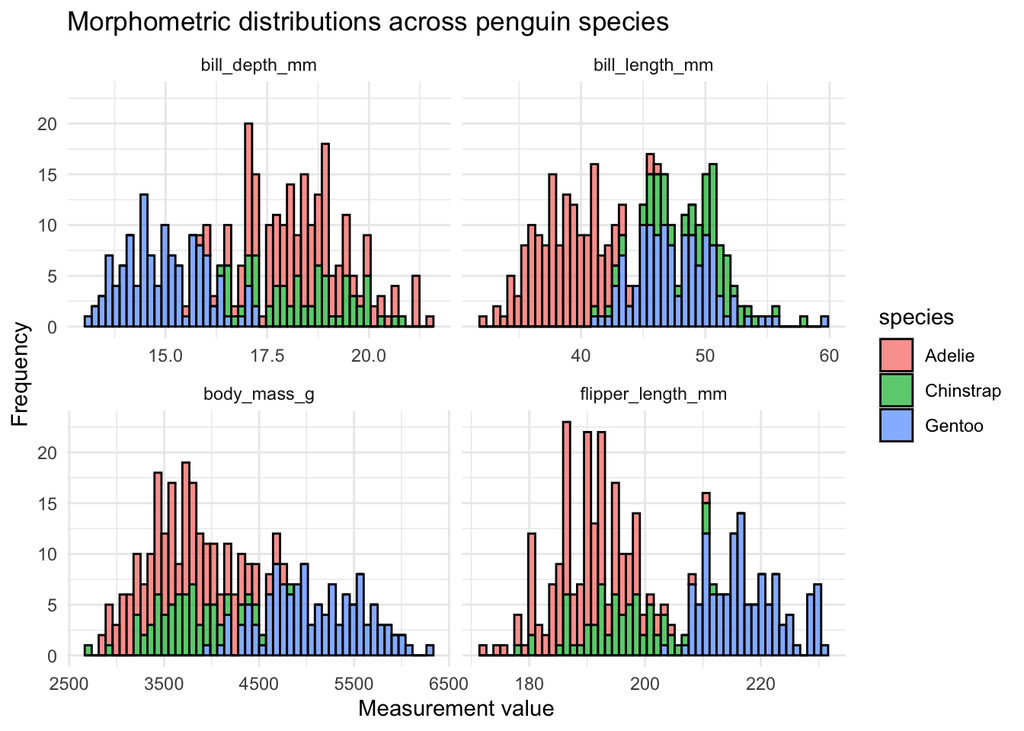

```r
penguins_long |>
  drop_na(value) |>
  ggplot(aes(x = value, fill = species)) +
  geom_histogram(bins = 50, alpha = 0.7, colour = "black") +
  facet_wrap(~ measurement_type, scales = "free_x") +
  theme_minimal() +
  labs(
    title = "Morphometric distributions across penguin species",
    x = "Measurement value",
    y = "Frequency"
  )
```

#Widening data with pivot_wider() Now, we will look at the reverse operation. Sometimes, it’s much easier for a reader to look at a wide table than a long, repetitive list. First, lets calculate the mean body mass for each species on each island using group_by() and summarise().

```r
mass_summary <- penguins |>
  drop_na(body_mass_g) |>
  group_by(species, island) |>
  summarise(mean_mass = mean(body_mass_g))
```

```
## `summarise()` has regrouped the output.
## ℹ Summaries were computed grouped by species and island.
## ℹ Output is grouped by species.
## ℹ Use `summarise(.groups = "drop_last")` to silence this message.
## ℹ Use `summarise(.by = c(species, island))` for per-operation grouping
##   (`?dplyr::dplyr_by`) instead.
```

```r
head(mass_summary)
```

```
## # A tibble: 5 × 3
## # Groups:   species [3]
##   species   island    mean_mass
##   <fct>     <fct>         <dbl>
## 1 Adelie    Biscoe        3710.
## 2 Adelie    Dream         3688.
## 3 Adelie    Torgersen     3706.
## 4 Chinstrap Dream         3733.
## 5 Gentoo    Biscoe        5076.
```

This output is technically tidy and computationally useful, but it is not ideal for publication presentation. We can use pivot_wider() to pull the island names up into columns, creating a clean matrix of species by island.

```r
mass_matrix <- mass_summary |>
  pivot_wider(
    names_from = island,
    values_from = mean_mass
  )

head(mass_matrix)
```

```
## # A tibble: 3 × 4
## # Groups:   species [3]
##   species   Biscoe Dream Torgersen
##   <fct>      <dbl> <dbl>     <dbl>
## 1 Adelie     3710. 3688.     3706.
## 2 Chinstrap    NA  3733.       NA
## 3 Gentoo     5076.   NA        NA
```

I prefer the way this looks.

#2.7 Separating and Uniting Data Tables In table3, we see the one column ‘rate’ contains two variables (cases and population). To address this, we can use separate() function, which separates one column into multiple columns wherever you designate.

```r
table3
```

```
## # A tibble: 6 × 3
##   country      year rate
##   <chr>       <dbl> <chr>
## 1 Afghanistan  1999 745/19987071
## 2 Afghanistan  2000 2666/20595360
## 3 Brazil       1999 37737/172006362
## 4 Brazil       2000 80488/174504898
## 5 China        1999 212258/1272915272
## 6 China        2000 213766/1280428583
```

Now we will separate the rate column into two columns.

```r
table3 %>%
  separate(rate, into = c("cases", "population"))
```

```
## # A tibble: 6 × 4
##   country      year cases  population
##   <chr>       <dbl> <chr>  <chr>
## 1 Afghanistan  1999 745    19987071
## 2 Afghanistan  2000 2666   20595360
## 3 Brazil       1999 37737  172006362
## 4 Brazil       2000 80488  174504898
## 5 China        1999 212258 1272915272
## 6 China        2000 213766 1280428583
```

Now, you can see there are two columns, cases and population. R knew to separate the numbers where the slash was. But, if you wanted to use specific characters to separate a column, you can put this into the argument:

```r
table3 %>%
  separate(rate, into = c("cases", "population"), sep = "/")
```

```
## # A tibble: 6 × 4
##   country      year cases  population
##   <chr>       <dbl> <chr>  <chr>
## 1 Afghanistan  1999 745    19987071
## 2 Afghanistan  2000 2666   20595360
## 3 Brazil       1999 37737  172006362
## 4 Brazil       2000 80488  174504898
## 5 China        1999 212258 1272915272
## 6 China        2000 213766 1280428583
```

```r
table3 %>%
  separate(rate, into = c("cases", "population"), convert = TRUE)
```

```
## # A tibble: 6 × 4
##   country      year  cases population
##   <chr>       <dbl>  <int>      <int>
## 1 Afghanistan  1999    745   19987071
## 2 Afghanistan  2000   2666   20595360
## 3 Brazil       1999  37737  172006362
## 4 Brazil       2000  80488  174504898
## 5 China        1999 212258 1272915272
## 6 China        2000 213766 1280428583
```

We can also seperate the last two digits of each year. This makes data less tidy, bu can be useful in some cases.

```r
table3 %>%
  separate(year, into = c("century", "year"), sep =2)
```

```
## # A tibble: 6 × 4
##   country     century year  rate
##   <chr>       <chr>   <chr> <chr>
## 1 Afghanistan 19      99    745/19987071
## 2 Afghanistan 20      00    2666/20595360
## 3 Brazil      19      99    37737/172006362
## 4 Brazil      20      00    80488/174504898
## 5 China       19      99    212258/1272915272
## 6 China       20      00    213766/1280428583
```

A new column has been added, century.

#Using unite(). unite() is the inverse of separate(). We use unite() to combine multiple columns into a single column. We will use it to combine century and year columns from above.

```r
table5 %>%
  unite(new, century, year, sep = "")
```

```
## # A tibble: 6 × 3
##   country     new   rate
##   <chr>       <chr> <chr>
## 1 Afghanistan 1999  745/19987071
## 2 Afghanistan 2000  2666/20595360
## 3 Brazil      1999  37737/172006362
## 4 Brazil      2000  80488/174504898
## 5 China       1999  212258/1272915272
## 6 China       2000  213766/1280428583
```

Nice! Now our columns are combined. We add sep=“” because we dont want any separator.

#2.8 Wrangling Strings & Dates When combining data from different sources-say, a government database, an oceanographic sensor, and handwritten field sheets-we inevitably run into formatting mismatches. A computer does not know that Nelly Bay, nelly_bay and NELLY BAY are the same location. Similarly, date formats vary wildy depending on the instrument or the researchers regional settings (e.g. DD/MM/YYYY vs. YYYY-MM-DD). So, we myst first standardize our text strings and date-times. The tidyverse includes two specialised packages for this… stringr for text and lubridate for dates.

#Standardising text with stringr. stringr package begins with str_.

```r
library(tidyverse)

#A remarkably messy data frame of field sites
messy_sites <- tibble(
  site_id = c("Nelly Bay", "nelly_bay", "NELLY BAY", "Geoffrey_Bay", "geoffrey bay")
)

#Using stringr within mutate to standardise the text:
clean_sites <- messy_sites |>
  mutate(
    #1. convert everything to lowercase
    site_clean = str_to_lower(site_id),
    #2. Replace any spaces with underscores
    site_clean = str_replace_all(site_clean, pattern = " ", replacement = "_"),
    #3. trim any leading or trailing whitespaces (invisible spaces at the ends)
    site_clean = str_trim(site_clean)
  )

print(clean_sites)
```

```
## # A tibble: 5 × 2
##   site_id      site_clean
##   <chr>        <chr>
## 1 Nelly Bay    nelly_bay
## 2 nelly_bay    nelly_bay
## 3 NELLY BAY    nelly_bay
## 4 Geoffrey_Bay geoffrey_bay
## 5 geoffrey bay geoffrey_bay
```

As we can see, all the different types of nelly bay variations and geoffery bay variations are now the same.

#Mastering time with lubridate If your dataset contains a date formatted as “25/12/2026” we would use the function dmy(). If the date is 2026-12-25, you use ymd().

```r
library(lubridate)

#Parsing different date formats.

date_1 <- dmy("25/12/2026")
date_2 <- ymd("2026-12-25")

#R now recognises these as identical Date objects.
date_1 == date_2
```

```
## [1] TRUE
```

```r
#A tibble of raw sensor data with messy character timestamp...
sensor_data <- tibble(
  raw_time = c("14-05-2026 08:30:00", "14-05-2026 08:45:00", "14-05-2026 09:00:00"),
  temperature = c(24.5, 24.6, 24.4)
)

#Converting character strings to true POSIXct datetime objects
sensor_clean <- sensor_data |>
  mutate(
    true_time = dmy_hms(raw_time)
  )

print(sensor_clean)
```

```
## # A tibble: 3 × 3
##   raw_time            temperature true_time
##   <chr>                     <dbl> <dttm>
## 1 14-05-2026 08:30:00        24.5 2026-05-14 08:30:00
## 2 14-05-2026 08:45:00        24.6 2026-05-14 08:45:00
## 3 14-05-2026 09:00:00        24.4 2026-05-14 09:00:00
```

#2.9 Relational Data: Joining Tables Bringing tables together based on a common identifying column, known as a key. We will set up two tables to demonstrate:

```r
#Table 1: Biological observation data.
observations <- tibble(
  site_code = c("NB", "GB", "MI", "NB", "HB"),
  species = c("Trout", "Snapper", "Trout", "Cod", "Trout"),
  count = c(5, 2, 1, 3, 8)
)

#Table 2: Spatial metadata
site_metadata <- tibble(
  site_code = c("NB", "GB", "MI", "NB", "HB"),
  zone = c("Marine National Park", "Conservation Park", "Habitat Protection", "General Use", "Other Use"),
  lat = c(-19.16, -19.15, -19.14, -19.12, -19.11)
)
```

The workhorse: left_ and right_join()